# Reproducible Research Assignment 1

Carolyn Chadwick

Tuesday, 12 May 2015

Background Assignment information is included in README.Rmd/HTML file

### Load & Explore data for Assignment

```r
    ## read the activity.csv text file & check its structure & that all 17568 observations exist
       unzip(zipfile="activity.zip")
       activity<-read.csv("activity.csv")
       str(activity)
```

```
## 'data.frame':    17568 obs. of  3 variables:
##  $ steps   : int  NA NA NA NA NA NA NA NA NA NA ...
##  $ date    : Factor w/ 61 levels "2012-10-01","2012-10-02",..: 1 1 1 1 1 1 1 1 1 1 ...
##  $ interval: int  0 5 10 15 20 25 30 35 40 45 ...
```

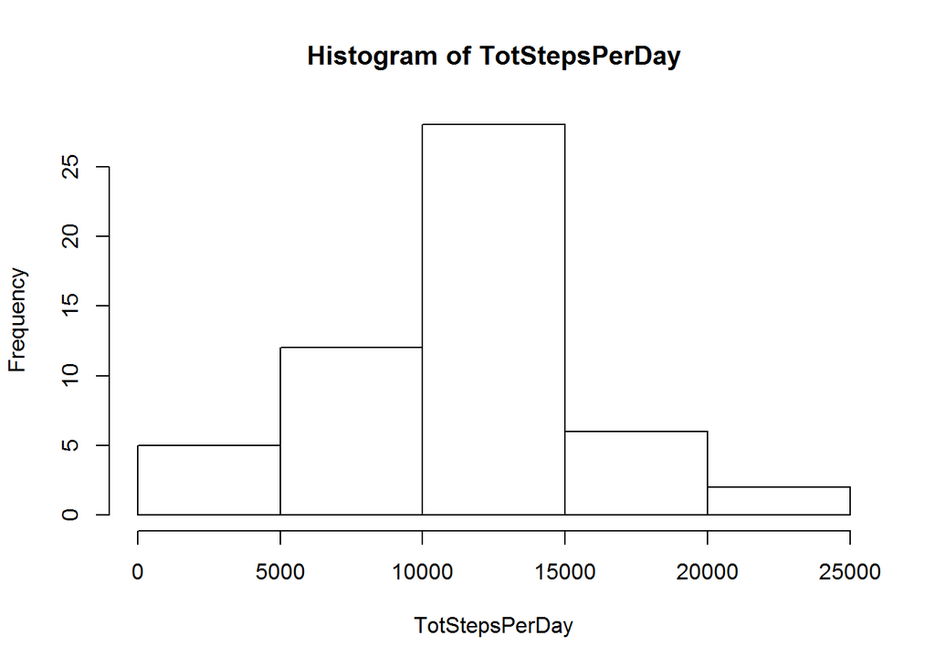

```r
    ## remove NA activities periods where no steps were recorded
       ActNotNA <- activity[ !(is.na(activity$steps)),]

    ## sum steps for all intervals in a day
       TotStepsPerDay <- rowsum(ActNotNA$steps, ActNotNA$date,
                                reorder = TRUE)

    ## 1  Histogram of total number of steps taken each day
          hist(TotStepsPerDay)
```

```r
    ## 2   Mean & median total number of steps taken per day
           MeanTotStepPerDay   <- mean( TotStepsPerDay)
           print(paste("Mean Total Steps per day = ",
                 round(MeanTotStepPerDay,0)))
```

```
## [1] "Mean Total Steps per day =  10766"
```

```r
           MedianTotStepPerDay <- median(TotStepsPerDay)
           print( paste("Median Total Steps per day = ",
                  round(MedianTotStepPerDay,0)))
```

```
## [1] "Median Total Steps per day =  10765"
```

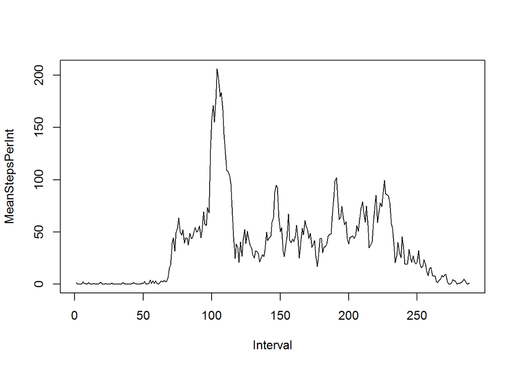

```r
    ## 3   Mean & median no. of steps for each interval all days
           ActNotNA$interval <- as.factor(ActNotNA$interval)
           MeanStepsPerInt <- tapply(ActNotNA$steps,
                                     ActNotNA$interval,
                                     FUN = mean
                                     )
           plot( MeanStepsPerInt,
                 xlab = "Interval",
                 type = "l"
                 )
```

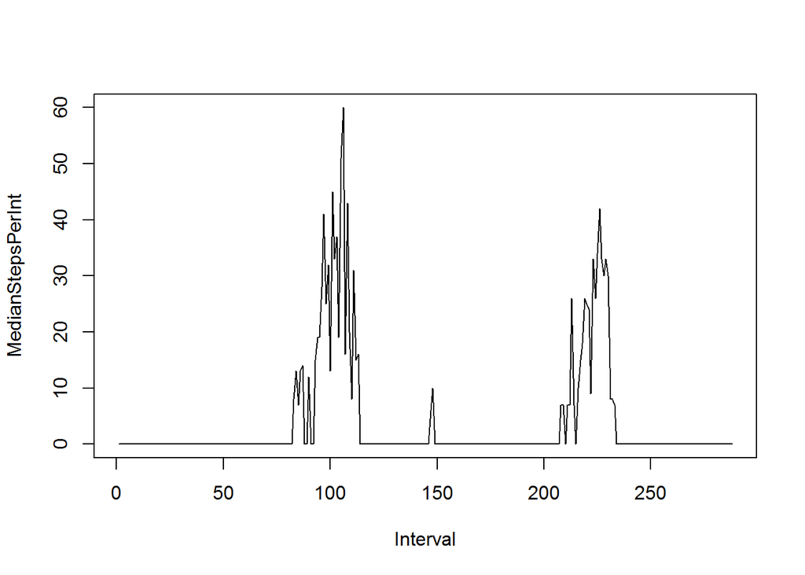

```r
           MedianStepsPerInt <- tapply(ActNotNA$steps,
                                     ActNotNA$interval,
                                     FUN = median
                                     )
           plot( MedianStepsPerInt,
                 xlab = "Interval",
                 type = "l"
                 )
```

```r
    ##  4  Busiest interval & mean steps taken in that interaval
           y <- which.max(MeanStepsPerInt)
           print( paste("Interval with highest average activity = ",
                         y))
```

```
## [1] "Interval with highest average activity =  104"
```

```r
           print( paste("Mean steps taken in that interval = ",
                        round(MeanStepsPerInt[y],)
                        ))
```

```
## [1] "Mean steps taken in that interval =  206"
```

### Imputing missing values

Removing NA data as done above leaves gaps in the time series. To obtain a continuous time series, missing values may be filled in with a relevant “imputed” value. The most appropriate choice of method of imputation varies by analysis data & objectives.

Assuming inactivity for NA’s & replacing them with 0 would lower mean activity per time period. This is not advised unless good reason exists for assuming inactivity. The other extreme is to assume that NA values indicate time periods where activity exceeded allowable maximum activity & was disqualified.

A sample mean ideally approaches the population mean, so the soundest default imputation method is to replace NA’s with the mean interval activity from the valid data (or the median if the data is skewed). Due to the nature of the missing intervals data (whole days in cases) further refinement of imputation of missing values using more refined daily means/medians (or interval across days means/medians) was not attempted.

From the histograms below is can be seen that replacing NA’s with interval means gives a preferred results to replacing NA’s with interval medians. The means replacments are all clustered in the column at the centre of the distribution. The median replacements are all clustered in the left-most tail of the distribution leading to a less Gaussian (therefore less ideal) distribution.

```r
  ##  5 Examine extent of NA records
      NAct <- length(activity$interval)
      NAs  <- NAct - length(ActNotNA$interval)
      NAPerc <- NAs/ NAct * 100

      print( paste( NAs, "(", round(NAPerc,0), "%) of ", NAct,
                  " activity readings were not available"))
```

```
## [1] "2304 ( 13 %) of  17568  activity readings were not available"
```

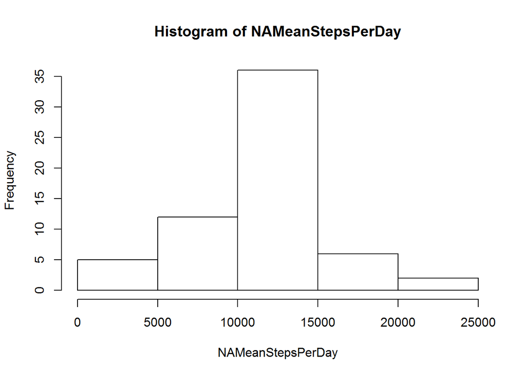

```r
      ## replace all NA's with Mean & median steps per interval
         NAMeanReps <- activity
         NAMeanReps[is.na(NAMeanReps)] <- MeanStepsPerInt
         NAMedianReps <- activity
         NAMedianReps[is.na(NAMedianReps)] <- MeanStepsPerInt

         NAMedianReps <- activity
         NAMedianReps[is.na(NAMedianReps)] <- MedianStepsPerInt
         NAMedianReps <- activity
         NAMedianReps[is.na(NAMedianReps)] <- MedianStepsPerInt

      ## sum steps for all intervals in a day
         NAMeanStepsPerDay <- rowsum(NAMeanReps$steps, NAMeanReps$date,
                                   reorder = TRUE)

         NAMedianStepsPerDay <- rowsum(NAMedianReps$steps, NAMedianReps$date,
                                   reorder = TRUE)

    ## 6  Make histogram of total number of steps taken each day
          hist(NAMeanStepsPerDay)
```

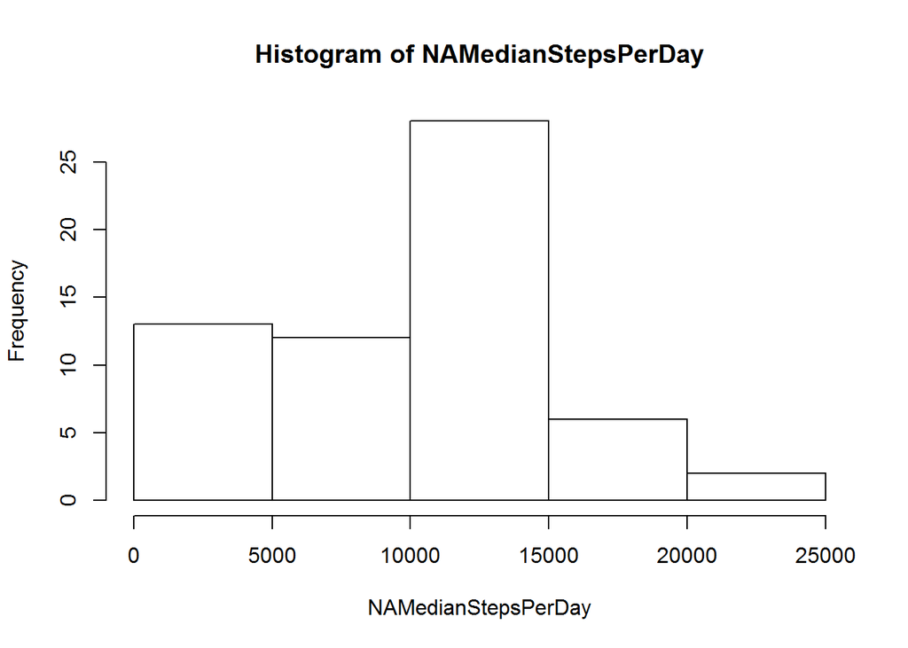

```r
          hist(NAMedianStepsPerDay)
```

```r
    ## 7  Show effect of Mean & median replacements of NA data on mean & median steps taken per day
          MeanNAMeanStepPerDay   <- mean( NAMeanStepsPerDay)
          print(paste("Replacing NA's with Mean steps per interval gives Mean Total Steps per day = ",
                round(MeanNAMeanStepPerDay,0),
                " compared with NA's removed mean of ",
                round(MeanTotStepPerDay,0)))
```

```
## [1] "Replacing NA's with Mean steps per interval gives Mean Total Steps per day =  10766  compared with NA's removed mean of  10766"
```

```r
          MedianNAMeanStepPerDay <- median(NAMeanStepsPerDay)
          print( paste("Replacing NA's with Mean steps per interval gives Median Total Steps per day = ",
                 round(MedianNAMeanStepPerDay,0),
                " compared with NA's median of ",
                round(MedianTotStepPerDay,0)))
```

```
## [1] "Replacing NA's with Mean steps per interval gives Median Total Steps per day =  10766  compared with NA's median of  10765"
```

```r
          MeanNAMedianStepPerDay   <- mean( NAMedianStepsPerDay)
          print(paste("Replacing NA's with Median steps per interval gives Mean Total Steps per day = ",
                round(MeanNAMeanStepPerDay,0),
                " compared with NA's removed mean of ",
                round(MeanTotStepPerDay,0)))
```

```
## [1] "Replacing NA's with Median steps per interval gives Mean Total Steps per day =  10766  compared with NA's removed mean of  10766"
```

```r
          MedianNAMedianStepPerDay <- median(NAMedianStepsPerDay)
          print( paste("Replacing NA's with Median steps per interval gives Median Total Steps per day = ",
                 round(MedianNAMedianStepPerDay,0),
                " compared with NA's median of ",
                round(MedianTotStepPerDay,0)))
```

```
## [1] "Replacing NA's with Median steps per interval gives Median Total Steps per day =  10395  compared with NA's median of  10765"
```

### Comparing Week day with weekend activity rates

Over weekends activity steps are more evenly distributed over all intervals with a lower mean than the daily peak activity found during week days.

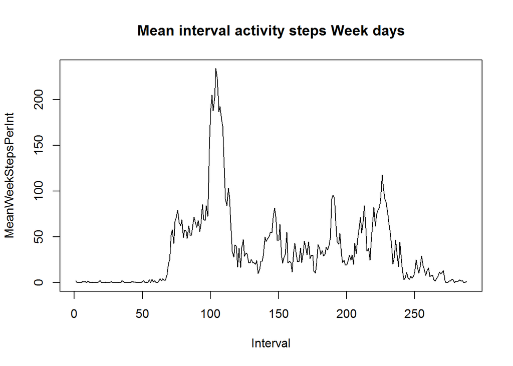

```r
  ##  8 Split data dates into week & weekend

      ActNotNA$DayOfWeek <- factor(weekdays(as.Date(ActNotNA$date)))
      ActNotNA$WeekEnd   <- ActNotNA$DayOfWeek %in% c("Saturday","Sunday")

      ActWeek    <- ActNotNA[! ActNotNA$WeekEnd,]
      ActWeekEnd <- ActNotNA[ ActNotNA$WeekEnd,]

  ##  9  Plot mean activity per interval comparing week days with weekends

      MeanWeekStepsPerInt <- tapply(ActWeek$steps,
                                    ActWeek$interval,
                                     FUN = mean
                                     )
           plot( MeanWeekStepsPerInt,
                 main = "Mean interval activity steps Week days",
                 xlab = "Interval",
                 type = "l"
                 )
```

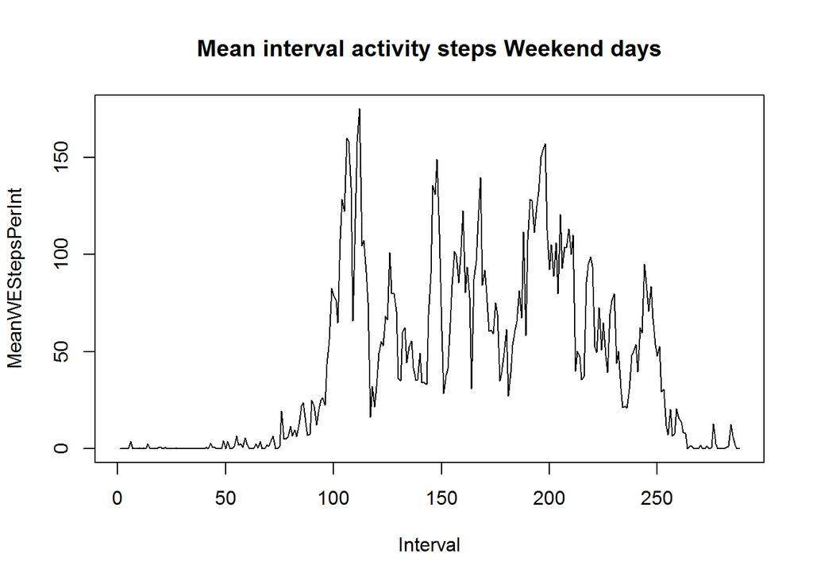

```r
      MeanWEStepsPerInt <- tapply(ActWeekEnd$steps,
                                  ActWeekEnd$interval,
                                     FUN = mean
                                     )
           plot( MeanWEStepsPerInt,
                 main = "Mean interval activity steps Weekend days",
                 xlab = "Interval",
                 type = "l"
                 )
```